# Stat Computing HW3

Yaniv Bronshtein

4/9/2022

**Library imports**

```r
library(tidyverse)
```

# Problem 1.

1. Generate 200 replicas of uniform [-pi,pi] and 200 normal with mean 0 and standard deviation 1/8. Set data x from this uniform, error epsilon from this normal distribution. The response y is by model: y = sin(x)+epsilon Fit the data with two types of smoothing techniques. Plot both the data and your fitted smooth curves. (b) The same as (a) except changing the standard deviation from 1/8 to 1/2. [Remark: Use a computer for you calculation; explain your analysis and results carefully]

```r
set.seed(1)
x <- runif(n=200,min=-pi,max=pi)
e1 <- rnorm(n=200,mean=0,sd=(1/8))
y1 <- sin(x) + e1
```

```r
set.seed(1)
e2 <- rnorm(n=200,mean=0,sd=(1/2))
y2 <- sin(x) + e2
```

**Fit the data with two smoothing techniques**

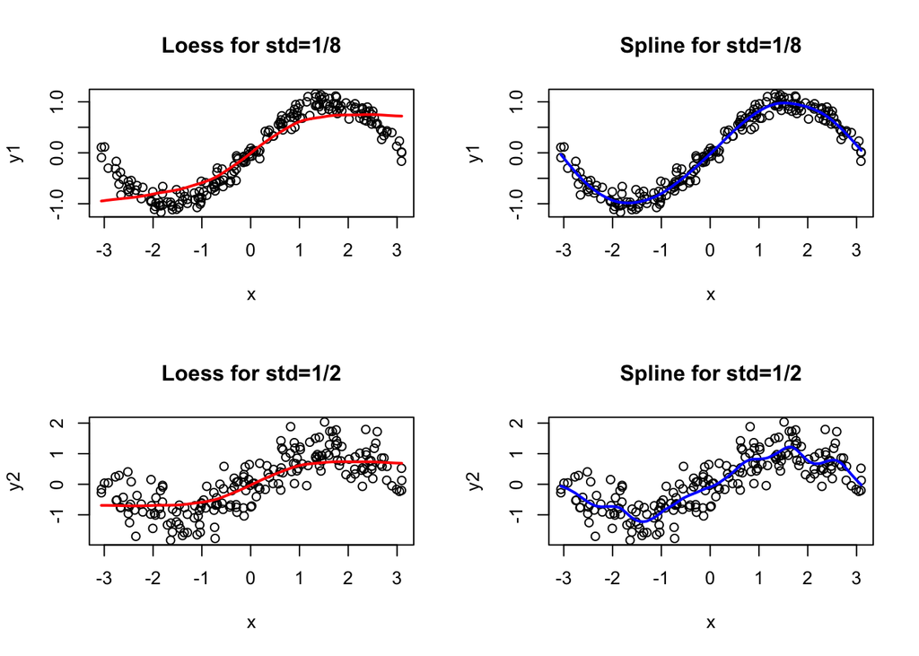

```r
par(mfrow=c(2,2))
plot(x,y1,main="Loess for std=1/8")
lines(loess.smooth(x,y1),lwd=2,col='red')

plot(x,y1,main="Spline for std=1/8")
lines(smooth.spline(x,y1),lwd=2,col='blue')

plot(x,y2,main="Loess for std=1/2")
lines(loess.smooth(x,y2),lwd=2,col='red')

plot(x,y2,main="Spline for std=1/2")
lines(smooth.spline(x,y2),lwd=2,col='blue')
```

*Based on the results, a spline fitting the data for error standard deviation of 1/8 provides the best fit.* *Loess provides the poorest fit for both values of standard deviation.* *Despite the difficulty of fitting for std=1/2, the spline consistently performs the better fit for both standard deviations*

# Problem 2.

1. Use a linear regression model to analyze the GAG in urine data in data frame GAGurine. Produce a chart to help a pediatrician to assess if a child’s GAG concentration is ’normal or not (hint: plot in one graph the estimated line and confidence bands at different levels)
2. Consider using a smooth regression to analyze the GAG in urine data [Remark: See the data set named “GAGurine.csv” in the assignment. Use a computer for you calculation; explain your analysis and results carefully]

**Read in the data**

```r
gag_urine_df <- read.csv('/Users/yanivbronshtein/Coding/Rutgers/Statistical_Computing_Repo/data/GAGurine.csv')
```

**Fit linear regression model**

```r
gag_lm <- lm(GAG~Age, data=gag_urine_df)
summary(gag_lm)
```

```
##
## Call:
## lm(formula = GAG ~ Age, data = gag_urine_df)
##
## Residuals:
##    Min     1Q Median     3Q    Max
## -9.950 -4.217 -1.596  2.477 36.470
##
## Coefficients:
##             Estimate Std. Error t value Pr(>|t|)
## (Intercept) 19.89381    0.52553   37.85   <2e-16 ***
## Age         -1.27253    0.07242  -17.57   <2e-16 ***
## ---
## Signif. codes:  0 '***' 0.001 '**' 0.01 '*' 0.05 '.' 0.1 ' ' 1
##
## Residual standard error: 6.386 on 312 degrees of freedom
## Multiple R-squared:  0.4974, Adjusted R-squared:  0.4958
## F-statistic: 308.7 on 1 and 312 DF,  p-value: < 2.2e-16
```

**Generate the physician growth chart

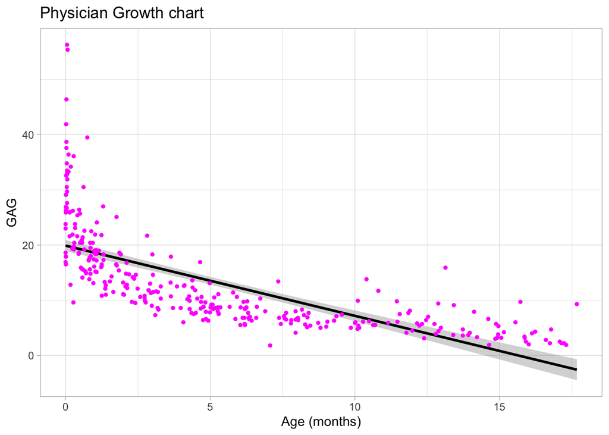

```r
GAG_plot <- ggplot(gag_urine_df, aes(Age, GAG)) +
    geom_smooth(method = "lm", se = TRUE, col = "black") +
    geom_point(size = 1, col = "magenta") +
    labs(x = "Age (months)", y = "GAG") +
    ggtitle("Physician Growth chart") +
    theme_light()

GAG_plot
```

*The physician chart above shows that the data is poorly fit with a linear model. Most of the observations are not on the regression curve.* **Fit the spline for the GAGURine data**

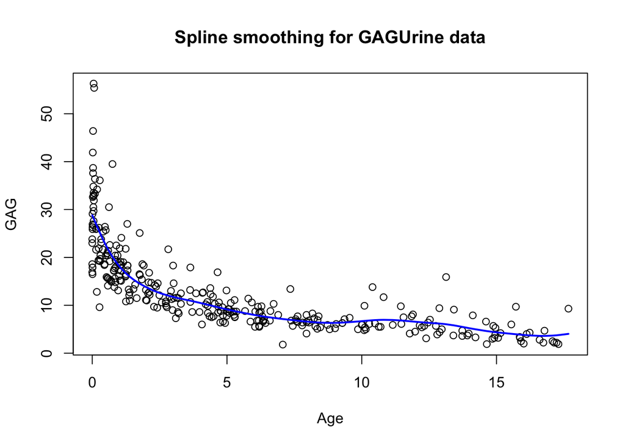

```r
x <- gag_urine_df$Age
y <- gag_urine_df$GAG
plot(x=x,
     y=y,
     main="Spline smoothing for GAGUrine data",
     xlab="Age",
     ylab="GAG")
lines(smooth.spline(x,y),lwd=2,col='blue')
```

# Problem 4

Write a computing code to calculate the integration from -5 to 5 of (x^3 − x<sup>2)exp{−x</sup>2/2} using Monte Carlo simulation with N samples from a uniform distribution, for N = 10, 100, 1000. For each choice of N, repeat the experiment for 500 times, compute the variance and visualize the relationship between the variance and N. [Remark: Use a computer for you calculation; explain your results carefully]

```r
# importing the modules


# limits of integration
a = -5
b = 5
N = 100

arr <- runif(N,a,b)


# variable to store sum of the functions of
# different values of x
integral <- 0.0

# function to calculate the sin of a particular
# value of x
f <- function(x){
  exponent <- -(x^2)/2
  return((x^3 - x^2)*exp(exponent))
}
# iterates and sums up values of different functions
# of x
for(elem in arr){
    integral <- integral + f(elem)
}
cat(integral)
```

```
## -20.34422
```

```r
# we get the answer by the formula derived adobe
ans = 1.0*(b-a)/N*integral

# prints the solution
cat("The value calculated by monte carlo integration is.",ans)
```

```
## The value calculated by monte carlo integration is. -2.034422
```

**Function to integrate**

```r
f <- function(x){
    exponent <- -(x^2)/2
    return((x^3 - x^2)*exp(exponent))
}
```

**Monte Carlo integration**

```r
monte_carlo_integral <- function(N){
  a <- -5
  b <- 5
  arr <- runif(N,a,b)


  # variable to store sum of the functions of
  # different values of x
  integral <- 0.0


  # iterates and sums up values of different functions
  # of x
  for(elem in arr){
      integral <- integral + f(elem)
  }
  # we get the answer by the formula derived adobe
  ans = (b-a)/N*integral

  return(ans)
}
```

**Compute the variances after 500 simulations**

```r
arr_N10 <- NULL; arr_N100 <- NULL; arr_N1000 <- NULL
for(i in 1:500) {
  arr_N10 <- c(arr_N10, monte_carlo_integral(10))
  arr_N100 <- c(arr_N100, monte_carlo_integral(100))
  arr_N1000 <- c(arr_N1000, monte_carlo_integral(1000))

}

var_N10 <- var(arr_N10)
var_N100 <- var(arr_N100)
var_N1000 <- var(arr_N1000)
```

**Plot the variance**

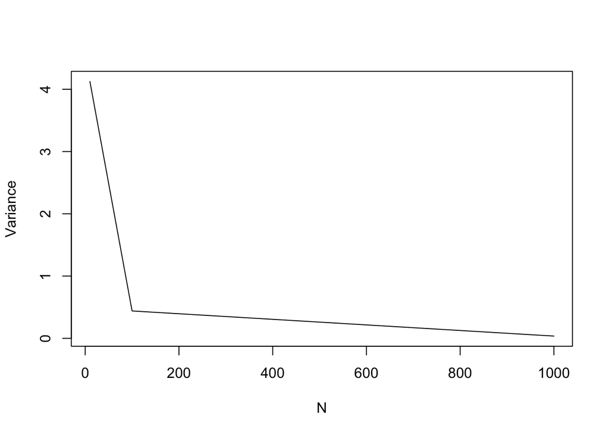

```r
N <- c(10,100,1000)
Variance <- c(var_N10, var_N100, var_N1000)

plot(x=N, y=Variance, type='l')
```

Over 500 iterations, we compute the variance estimates and utilize the uniform distribution in our monte carlo simulation. As the value of N increases, the variance decreases and the accuracy of the integration value increases(verified using wolfram alpha).